# Using a VariantExperiment data object to manage COVID19 data

Jerome Ambroise, Laurent Gatto, Julie Hurel, Bertrand Bearzatto, Jean-Luc Gala

April 05, 2021,20:36

In this document we illustrate the advantages of using the *VariantExperiment* Bioconductor package for handling SARS-CoV-2 genomic data and associated metadata. For more details, we invite you to read the associated publication (‘On the many advantages of using the VariantExperiment Bioconductor package for storing, exchanging and analyzing SARS-CoV-2 genomic data and associated metadata’ available on bioRxiv.org).

# Creation of the VariantExperiment object

We start by summarising how the data object is created from the `variant.q20.vcf` file and proceed describing how to annotate the object with additional feature and sample level metadata.

## Loading required packages

```r
library(SummarizedExperiment)
library(VariantExperiment)
library(VariantAnnotation)
library(SeqArray)
```

## Creation of the object based on a vcf file

```r
vcf.header <- seqVCF_Header('./variant.q20.vcf')
seqVCF2GDS(vcf.fn = './variant.q20.vcf',
           out.fn = './sarscov2.gds',
           info.import = c('GT','DP'))
```

```
## Mon Apr  5 20:37:08 2021
## Variant Call Format (VCF) Import:
##     file(s):
##         variant.q20.vcf (40.5K)
##     file format: VCFv4.2
##     the number of sets of chromosomes (ploidy): 1
##     the number of samples: 10
##     genotype storage: bit2
##     compression method: LZMA_RA
##     # of samples: 10
## Output:
##     ./sarscov2.gds
## Parsing 'variant.q20.vcf':
## + genotype/data   { Bit2 1x10x38 LZMA_ra, 42B }
## Digests:
##     sample.id  [md5: 4466f775459d44be87bbda4b0f143344]
##     variant.id  [md5: 5093464fcf3d0d538dacce1010368034]
##     position  [md5: b13632ee3ffcf80096760a564183dd64]
##     chromosome  [md5: d022439f8e99707fa1188aefebeaba47]
##     allele  [md5: 80e142bc2389c6f3f2a881eb8c5dbcfa]
##     genotype  [md5: bdad290f97f27115968b4e5e8d7e4aa8]
##     annotation/id  [md5: 880c7da9a4994d6b5f814c910d909c2c]
##     annotation/qual  [md5: db0b960602bd61848e86f4757e1ea982]
##     annotation/filter  [md5: 2d6eafb2bc0c89e04870ec804ee92be7]
##     annotation/info/DP  [md5: 9b4334216949e875dc79c533c92721ce]
##     annotation/format/GQ  [md5: 6e6dcb39f4b68c5a7dc6ad670c6ff366]
##     annotation/format/GL  [md5: 98c3809f0db5856c53cb188bf2be88c0]
##     annotation/format/DP  [md5: 417df6ccbfdb59a0ced9bc2115d6c5b7]
##     annotation/format/AD  [md5: 4ed8360697b6786abaee9eabd0c33971]
##     annotation/format/RO  [md5: c03925fbe2c83d870f6547343532f5c3]
##     annotation/format/QR  [md5: bda132013fa4d7411d4a27a884a0a717]
##     annotation/format/AO  [md5: c224ed89558024d422826d889d69e521]
##     annotation/format/QA  [md5: db18a4e58c5ca0faafeb7af1e8b8c126]
##     annotation/format/MIN_DP  [md5: 6e6dcb39f4b68c5a7dc6ad670c6ff366]
## Done.
## Mon Apr  5 20:37:09 2021
## Optimize the access efficiency ...
## Clean up the fragments of GDS file:
##     open the file './sarscov2.gds' (23.1K)
##     # of fragments: 199
##     save to './sarscov2.gds.tmp'
##     rename './sarscov2.gds.tmp' (21.9K, reduced: 1.2K)
##     # of fragments: 95
## Mon Apr  5 20:37:09 2021
```

```r
sarscov2_ve <- makeVariantExperimentFromGDS('./sarscov2.gds')
assayNames(sarscov2_ve) <- c('genotype','DP')
sarscov2_ve
```

```
## class: VariantExperiment
## dim: 38 10
## metadata(0):
## assays(2): genotype DP
## rownames(38): 1 2 ... 37 38
## rowData names(6): ID ALT ... FILTER info_DP
## colnames(10): SRR12881622_1 SRR12881620_1 ... SRR12881617_1
##   SRR12881618_1
## colData names(0):
```

## Sample annotations/metadata (aka `colData`)

```r
col_data <- DataFrame(read.csv('coldata.csv'))
rownames(col_data) <- col_data$Sample.ID
col_data <- col_data[match(colnames(sarscov2_ve), col_data$SRA.ID), ]
stopifnot(identical(colnames(sarscov2_ve), col_data$SRA.ID))
SummarizedExperiment::colData(sarscov2_ve) <- col_data
```

## Feature annotations/medata (aka `rowData`)

```r
vcffile.fb <- readVcf('variant.q20.vcf')
SummarizedExperiment::rowRanges(sarscov2_ve) <- SummarizedExperiment::rowRanges(vcffile.fb)
```

## Annotation of variants of interest/concern

As an example, we define two variants of concern, VOC1 and VOC2:

- VOC1 is defined by 2 loci, namely `"MN908947.3:5224_TAAAAAG/TAAAAG"` and `"MN908947.3:22487_GAAAAAG/GAAAAG"`
- VOC2 is defined by `"MN908947.3:29377_TAAAAAG/TAAAAG"`

These VOCs are defined as logical columns in the rowData slot, with matching loci set to `TRUE`.

```r
rowData(sarscov2_ve)$VOC1 <- rowData(sarscov2_ve)$VOC2 <- FALSE
rowData(sarscov2_ve)$VOC1[c(7, 26)] <- TRUE
rowData(sarscov2_ve)$VOC2[38] <- TRUE
```

Below, we manually define which samples have been infected by specific variants of concern. Invection by specific variants of concern could also be automatically computed from the VOC rowData annotation.

```r
sarscov2_ve$has_VOC1 <- sarscov2_ve$has_VOC2 <- FALSE
sarscov2_ve$has_VOC1[c(2, 6, 9)] <- TRUE
sarscov2_ve$has_VOC2[c(3, 5, 8)] <- TRUE
```

## Serialisation of the object

```r
saveRDS(sarscov2_ve, 'sarscov2_ve.rds')
```

# Usage of the VariantExperiment object

## Data loading

Once created, the `VariantExperiment` object can simply be reloaded and readily used.

```r
library(VariantExperiment)
sarscov2_ve <- readRDS('sarscov2_ve.rds')
```

The object contains 38 variants sequenced in 10 different samples.

```r
sarscov2_ve
```

```
## class: VariantExperiment
## dim: 38 10
## metadata(0):
## assays(2): genotype DP
## rownames(38): MN908947.3:241_C/T MN908947.3:313_C/T ...
##   MN908947.3:28882_GG/AC MN908947.3:29377_TAAAAAG/TAAAAG
## rowData names(7): paramRangeID REF ... VOC2 VOC1
## colnames(10): ax1233130 ax1233128 ... ax1233125 ax1233126
## colData names(19): Sample.ID Date ... has_VOC2 has_VOC1
```

## `Assay`: genomic data

The assays slots stores the genomic data, including the called genotype (encoded as 0, 1, or 2) and a quality metrics such as read depth (DP) for the illustration). Other quality metrics such as the phred score, or any quantitative data of identical dimension could be added.

```r
assay(sarscov2_ve, "genotype")
```

```
## <38 x 10 x 1> array of class DelayedArray and type "integer":
## ,,1
##                                 ax1233130 ax1233128 ax1233129 ... ax1233124
##              MN908947.3:241_C/T         1         1         0   .         0
##              MN908947.3:313_C/T         1         1         0   .         0
##                             ...         .         .         .   .         .
##          MN908947.3:28882_GG/AC         1         1         1   .         0
## MN908947.3:29377_TAAAAAG/TAAAAG         0         0         1   .         1
##                                 ax1233125 ax1233126
##              MN908947.3:241_C/T         0         0
##              MN908947.3:313_C/T         0         0
##                             ...         .         .
##          MN908947.3:28882_GG/AC         0         0
## MN908947.3:29377_TAAAAAG/TAAAAG         0         0
```

```r
assay(sarscov2_ve, "DP")
```

```
## <38 x 10> matrix of class DelayedMatrix and type "integer":
##                                  ax1233130 ax1233128 ax1233129 ... ax1233124
##               MN908947.3:241_C/T      3027      3462        99   .        27
##               MN908947.3:313_C/T      3471      3880       113   .        29
##              MN908947.3:1408_G/T       214       151         2   .         4
## MN908947.3:1813_TAAAAAAG/TAAAAAG        23       122        15   .        18
##          MN908947.3:3036_TCT/TTT      3367      3368       761   .       422
##                              ...         .         .         .   .         .
##             MN908947.3:26801_C/T      2122      2569       502   .       117
##         MN908947.3:28309_ACC/ACT      2979      1044        12   .         8
##         MN908947.3:28879_TAG/TAA       567       314         5   .         6
##           MN908947.3:28882_GG/AC       603       327         6   .         7
##  MN908947.3:29377_TAAAAAG/TAAAAG      2012      1510       117   .        10
##                                  ax1233125 ax1233126
##               MN908947.3:241_C/T       943      4670
##               MN908947.3:313_C/T      1046      5484
##              MN908947.3:1408_G/T        34        95
## MN908947.3:1813_TAAAAAAG/TAAAAAG        16        30
##          MN908947.3:3036_TCT/TTT      1241      6142
##                              ...         .         .
##             MN908947.3:26801_C/T       536      1467
##         MN908947.3:28309_ACC/ACT       201      1117
##         MN908947.3:28879_TAG/TAA        54       122
##           MN908947.3:28882_GG/AC        74       159
##  MN908947.3:29377_TAAAAAG/TAAAAG       142      1300
```

It now becomes easy to produce a graphical overview of the genotypes of the read depth of a dataset by plotting the respective assay heatmap.

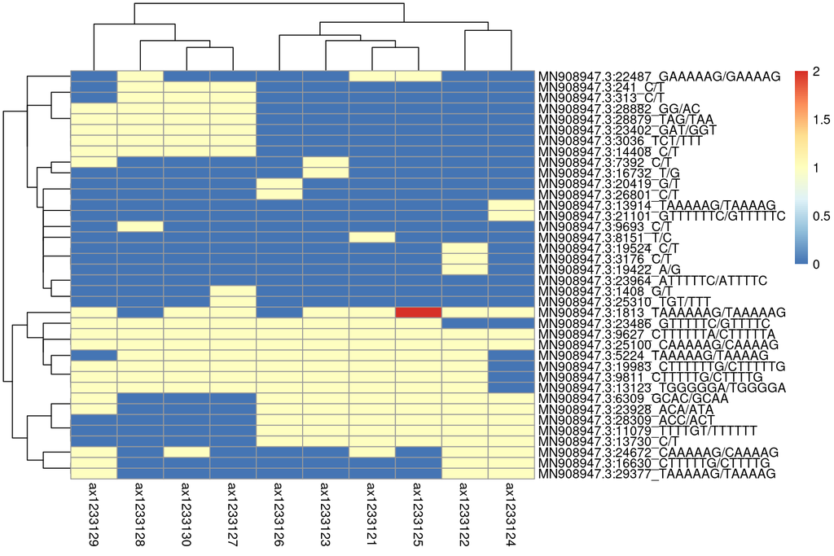

Heatmap of the virus genotypes.

```r
pheatmap::pheatmap(assay(sarscov2_ve, "genotype"))
```

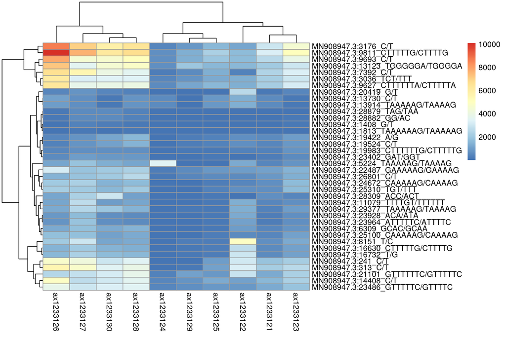

Heatmap of the sequencing read depth illustrating how some samples have systematic low read depth (blue).

```r
pheatmap::pheatmap(assay(sarscov2_ve, "DP"))
```

## `colData`: sample annotations/metadata

As shown here, the `colData` slot stores the annotation/metadata associated to each sample (sample, pre-analytic, analytic, bioinformatics)

```r
SummarizedExperiment::colData(sarscov2_ve)
```

```
## DataFrame with 10 rows and 19 columns
##             Sample.ID        Date      PatientID        SRA.ID     Country
##           <character> <character>    <character>   <character> <character>
## ax1233130   ax1233130  20/03/2030 ID.BEL.0111232 SRR12881622_1     Belgium
## ax1233128   ax1233128  20/03/2028 ID.BEL.0111230 SRR12881620_1     Belgium
## ax1233129   ax1233129  20/03/2029 ID.BEL.0111231 SRR12881621_1     Belgium
## ax1233127   ax1233127  20/03/2027 ID.BEL.0111229 SRR12881619_1     Belgium
##                 Age         Sex     Diabete Hypertension     Obesity
##           <integer> <character> <character>  <character> <character>
## ax1233130        58           F          no           no          no
## ax1233128        67           F          no           no          no
## ax1233129        88           M          no           no          no
## ax1233127        55           F          no           no          no
##               Vaccine Sample.type  Sample.conservation library_preparation
##           <character> <character>          <character>         <character>
## ax1233130          No    salivary congelation.minus.20            amplicon
## ax1233128          No    salivary congelation.minus.20            amplicon
## ax1233129         Yes    salivary congelation.minus.20            amplicon
## ax1233127          No    salivary congelation.minus.20            amplicon
##           sequencing_technology Bioinformatics_mapping
##                     <character>            <character>
## ax1233130            ONT_Minion          minimap2 2.17
## ax1233128            ONT_Minion          minimap2 2.17
## ax1233129            ONT_Minion          minimap2 2.17
## ax1233127            ONT_Minion          minimap2 2.17
##           Bioinformatics.variantcalling  has_VOC2  has_VOC1
##                             <character> <logical> <logical>
## ax1233130              freebayes 1.3.11     FALSE     FALSE
## ax1233128               freebayes 1.3.9     FALSE      TRUE
## ax1233129              freebayes 1.3.10      TRUE     FALSE
## ax1233127               freebayes 1.3.8     FALSE     FALSE
##  [ reached getOption("max.print") -- omitted 6 rows ]
```

## `rowData`: feature annotationnns

Finally, the `rowData` includes the description of each mutation. This slot could also include an indicator reflecting if this variant is currently considered as a Variant of Concern (VOC) or Variant of high Concern.

```r
SummarizedExperiment::rowRanges(sarscov2_ve)
```

```
## GRanges object with 38 ranges and 7 metadata columns:
##                                      seqnames      ranges strand | paramRangeID
##                                         <Rle>   <IRanges>  <Rle> |     <factor>
##                 MN908947.3:241_C/T MN908947.3         241      * |           NA
##                 MN908947.3:313_C/T MN908947.3         313      * |           NA
##                MN908947.3:1408_G/T MN908947.3        1408      * |           NA
##   MN908947.3:1813_TAAAAAAG/TAAAAAG MN908947.3   1813-1820      * |           NA
##            MN908947.3:3036_TCT/TTT MN908947.3   3036-3038      * |           NA
##                                ...        ...         ...    ... .          ...
##               MN908947.3:26801_C/T MN908947.3       26801      * |           NA
##           MN908947.3:28309_ACC/ACT MN908947.3 28309-28311      * |           NA
##           MN908947.3:28879_TAG/TAA MN908947.3 28879-28881      * |           NA
##             MN908947.3:28882_GG/AC MN908947.3 28882-28883      * |           NA
##    MN908947.3:29377_TAAAAAG/TAAAAG MN908947.3 29377-29383      * |           NA
##                                               REF                ALT       QUAL
##                                    <DNAStringSet> <DNAStringSetList>  <numeric>
##                 MN908947.3:241_C/T              C                  T 150071.000
##                 MN908947.3:313_C/T              C                  T 142330.000
##                MN908947.3:1408_G/T              G                  T   2685.190
##   MN908947.3:1813_TAAAAAAG/TAAAAAG       TAAAAAAG     TAAAAAG,TAAAAG    251.646
##            MN908947.3:3036_TCT/TTT            TCT                TTT 119014.000
##                                ...            ...                ...        ...
##               MN908947.3:26801_C/T              C                  T    9717.26
##           MN908947.3:28309_ACC/ACT            ACC                ACT   11358.90
##           MN908947.3:28879_TAG/TAA            TAG                TAA   13987.80
##             MN908947.3:28882_GG/AC             GG                 AC   14863.70
##    MN908947.3:29377_TAAAAAG/TAAAAG        TAAAAAG             TAAAAG    2216.31
##                                         FILTER      VOC2      VOC1
##                                    <character> <logical> <logical>
##                 MN908947.3:241_C/T           .     FALSE     FALSE
##                 MN908947.3:313_C/T           .     FALSE     FALSE
##                MN908947.3:1408_G/T           .     FALSE     FALSE
##   MN908947.3:1813_TAAAAAAG/TAAAAAG           .     FALSE     FALSE
##            MN908947.3:3036_TCT/TTT           .     FALSE     FALSE
##                                ...         ...       ...       ...
##               MN908947.3:26801_C/T           .     FALSE     FALSE
##           MN908947.3:28309_ACC/ACT           .     FALSE     FALSE
##           MN908947.3:28879_TAG/TAA           .     FALSE     FALSE
##             MN908947.3:28882_GG/AC           .     FALSE     FALSE
##    MN908947.3:29377_TAAAAAG/TAAAAG           .      TRUE     FALSE
##   -------
##   seqinfo: 1 sequence from an unspecified genome
```

## Data manipuation and subsetting

Here we illustrate how to subset the object. For the demonstration we select only data:

- from patient with obesity (Obesity = yes)
- mutation with a start position < 5000

```r
sel_start <- start(SummarizedExperiment::rowRanges(sarscov2_ve)) < 5000
sel_obesity <- sarscov2_ve$Obesity == 'yes'

ve2 <- sarscov2_ve[sel_start, sel_obesity]
ve2
```

```
## class: VariantExperiment
## dim: 6 2
## metadata(0):
## assays(2): genotype DP
## rownames(6): MN908947.3:241_C/T MN908947.3:313_C/T ...
##   MN908947.3:3036_TCT/TTT MN908947.3:3176_C/T
## rowData names(7): paramRangeID REF ... VOC2 VOC1
## colnames(2): ax1233122 ax1233125
## colData names(19): Sample.ID Date ... has_VOC2 has_VOC1
```

As shown here the selection is performed in one operation for both the rowData, colData and assay(s). This property therefore ensures to keep a perfect synchronization of genomic data with metadata.

We can also make use the the VOC/VOI definition in the rowData slot to extract and focus on the set of mutated loci of each variant:

```r
voc1 <- sarscov2_ve[rowData(sarscov2_ve)$VOC1, ]
assay(voc1, "genotype")
```

```
## <2 x 10 x 1> array of class DelayedArray and type "integer":
## ,,1
##                                 ax1233130 ax1233128 ... ax1233125 ax1233126
## MN908947.3:5224_TAAAAAG/TAAAAG          1         1   .         1         1
## MN908947.3:22487_GAAAAAG/GAAAAG         0         1   .         1         0
```

```r
SummarizedExperiment::rowRanges(voc1)
```

```
## GRanges object with 2 ranges and 7 metadata columns:
##                                     seqnames      ranges strand | paramRangeID
##                                        <Rle>   <IRanges>  <Rle> |     <factor>
##    MN908947.3:5224_TAAAAAG/TAAAAG MN908947.3   5224-5230      * |           NA
##   MN908947.3:22487_GAAAAAG/GAAAAG MN908947.3 22487-22493      * |           NA
##                                              REF                ALT      QUAL
##                                   <DNAStringSet> <DNAStringSetList> <numeric>
##    MN908947.3:5224_TAAAAAG/TAAAAG        TAAAAAG             TAAAAG 5127.7800
##   MN908947.3:22487_GAAAAAG/GAAAAG        GAAAAAG             GAAAAG   37.3753
##                                        FILTER      VOC2      VOC1
##                                   <character> <logical> <logical>
##    MN908947.3:5224_TAAAAAG/TAAAAG           .     FALSE      TRUE
##   MN908947.3:22487_GAAAAAG/GAAAAG           .     FALSE      TRUE
##   -------
##   seqinfo: 1 sequence from an unspecified genome
```

```r
voc2 <- sarscov2_ve[rowData(sarscov2_ve)$VOC2, ]
assay(voc2, "genotype")
```

```
## <1 x 10 x 1> array of class DelayedArray and type "integer":
## ,,1
##      ax1233130 ax1233128 ax1233129 ... ax1233124 ax1233125 ax1233126
## [1,]         0         0         1   .         1         0         0
```

```r
SummarizedExperiment::rowRanges(voc2)
```

```
## GRanges object with 1 range and 7 metadata columns:
##                                     seqnames      ranges strand | paramRangeID
##                                        <Rle>   <IRanges>  <Rle> |     <factor>
##   MN908947.3:29377_TAAAAAG/TAAAAG MN908947.3 29377-29383      * |           NA
##                                              REF                ALT      QUAL
##                                   <DNAStringSet> <DNAStringSetList> <numeric>
##   MN908947.3:29377_TAAAAAG/TAAAAG        TAAAAAG             TAAAAG   2216.31
##                                        FILTER      VOC2      VOC1
##                                   <character> <logical> <logical>
##   MN908947.3:29377_TAAAAAG/TAAAAG           .      TRUE     FALSE
##   -------
##   seqinfo: 1 sequence from an unspecified genome
```

Below, we use the sample-level metadata to extract the samples that have been annotated as having been infected by certain variants of concern:

```r
has_VOC1 <- sarscov2_ve[, sarscov2_ve$has_VOC1]
assay(has_VOC1, "genotype")
```

```
## <38 x 3 x 1> array of class DelayedArray and type "integer":
## ,,1
##                                 ax1233128 ax1233121 ax1233125
##              MN908947.3:241_C/T         1         0         0
##              MN908947.3:313_C/T         1         0         0
##                             ...         .         .         .
##          MN908947.3:28882_GG/AC         1         0         0
## MN908947.3:29377_TAAAAAG/TAAAAG         0         0         0
```

```r
has_VOC2 <- sarscov2_ve[, sarscov2_ve$has_VOC2]
assay(has_VOC2, "genotype")
```

```
## <38 x 3 x 1> array of class DelayedArray and type "integer":
## ,,1
##                                 ax1233129 ax1233122 ax1233124
##              MN908947.3:241_C/T         0         0         0
##              MN908947.3:313_C/T         0         0         0
##                             ...         .         .         .
##          MN908947.3:28882_GG/AC         1         0         0
## MN908947.3:29377_TAAAAAG/TAAAAG         1         1         1
```

Both subsetting can of course be applied simultaneously to extract the variants of concern loci in the patients that have been infected by that particular VOC:

```r
is_voc1 <- sarscov2_ve[rowData(sarscov2_ve)$VOC1, sarscov2_ve$has_VOC1]
assay(is_voc1, "genotype")
```

```
## <2 x 3 x 1> array of class DelayedArray and type "integer":
## ,,1
##                                  sample.id
## variant.id                        ax1233128 ax1233121 ax1233125
##   MN908947.3:5224_TAAAAAG/TAAAAG          1         1         1
##   MN908947.3:22487_GAAAAAG/GAAAAG         1         1         1
```

```r
is_voc2 <- sarscov2_ve[rowData(sarscov2_ve)$VOC2, sarscov2_ve$has_VOC2]
assay(is_voc2, "genotype")
```

```
## <1 x 3 x 1> array of class DelayedArray and type "integer":
## ,,1
##       sample.id
## NA     ax1233129 ax1233122 ax1233124
##   [1,]         1         1         1
```

Below, we focus on ranges **and** sample defining and infected by VOC1. We illustrate how the definition of a variant of interest, as encoded in the `VOC1` indicator, is used to extract the genomic sites that define it (`voc1_ranges` variable). The `voc1_sample` variable selects the samples that have been annotated as being infected by that variant.

```r
voc1_ranges <- rowData(sarscov2_ve)$VOC1
voc1_sample <- voc1$has_VOC1
```

We then show how the 3 samples have the alternative allele (a deletion) in the 2 sites at positions 5224-5230 and 22487-22493 respectively.

```r
assay(sarscov2_ve[voc1_ranges, voc1_sample], "genotype")
```

```
## <2 x 3 x 1> array of class DelayedArray and type "integer":
## ,,1
##                                  sample.id
## variant.id                        ax1233128 ax1233121 ax1233125
##   MN908947.3:5224_TAAAAAG/TAAAAG          1         1         1
##   MN908947.3:22487_GAAAAAG/GAAAAG         1         1         1
```

```r
SummarizedExperiment::rowRanges(sarscov2_ve[voc1_ranges, ])
```

```
## GRanges object with 2 ranges and 7 metadata columns:
##                                     seqnames      ranges strand | paramRangeID
##                                        <Rle>   <IRanges>  <Rle> |     <factor>
##    MN908947.3:5224_TAAAAAG/TAAAAG MN908947.3   5224-5230      * |           NA
##   MN908947.3:22487_GAAAAAG/GAAAAG MN908947.3 22487-22493      * |           NA
##                                              REF                ALT      QUAL
##                                   <DNAStringSet> <DNAStringSetList> <numeric>
##    MN908947.3:5224_TAAAAAG/TAAAAG        TAAAAAG             TAAAAG 5127.7800
##   MN908947.3:22487_GAAAAAG/GAAAAG        GAAAAAG             GAAAAG   37.3753
##                                        FILTER      VOC2      VOC1
##                                   <character> <logical> <logical>
##    MN908947.3:5224_TAAAAAG/TAAAAG           .     FALSE      TRUE
##   MN908947.3:22487_GAAAAAG/GAAAAG           .     FALSE      TRUE
##   -------
##   seqinfo: 1 sequence from an unspecified genome
```

# Further reading

The `VariantExperiment` package vignettes

- [VariantExperiment: A RangedSummarizedExperiment Container for VCF/GDS Data with GDS Backend](http://bioconductor.org/packages/release/bioc/vignettes/VariantExperiment/inst/doc/VariantExperiment-class.html)
- [VariantExperiment methods](http://bioconductor.org/packages/release/bioc/vignettes/VariantExperiment/inst/doc/VariantExperiment-methods.html)